# info_metrics_dec_14 slides

```python
from adsy.display import extended_styles
extended_styles()
```

## Estimating Parameters of a Level-K games using GME

Justin Grana

Summer 2014

## Outline

- Net-Form Games (and Multi-Agent influence diagrams)
- Level - K
- The Level-K Quantal Response Model
- Relaxing Assumptions

## Didactic Example

- Two firms must simultaneously choose a production quantity from a finite set to maximize profits.
- Demand can be either 'High' or 'Low', each representing a different demand function.
- Firm 1 observes the market demand function perfectly
- Firm 2 does not know the demand function exactly but receives a signal of 'H' or 'L'.

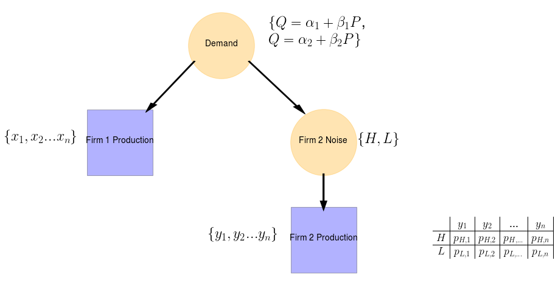

```python
%matplotlib inline
from matplotlib import pyplot as plt
from adsy.display import extended_styles
from matplotlib import rc
rc('text', usetex=True)
fig, ax = plt.subplots()
fig.set_size_inches(9, 8)
ax.scatter([5], [5], marker = "o", s=11800, alpha=.3, color = 'orange')
ax.text(5, 5, 'Demand', horizontalalignment='center', size=14)
ax.scatter([3.5], [2.5], marker = 's', s=11800, alpha=.3)
ax.text(3.5, 2.5, 'Firm 1 Production', horizontalalignment='center', size=14)
ax.scatter([6.5], [2.5], marker = 'o', s=11800, alpha = .3, color='orange')
ax.text(6.5, 2.5, 'Firm 2 Noise', horizontalalignment='center', size=14)
ax.scatter([6.5], [0], marker ='s', s=11800, alpha = .3 )
ax.text(6.5, 0, 'Firm 2 Production', horizontalalignment='center', size=14)
ax.arrow(4.6, 4.6, -.6, -1.1, head_length=.25, head_width=.1, width=.02, color='black')
ax.arrow(5.4, 4.6, .7, -1.15, head_length=.25, head_width=.1, width=.02, color='black')
ax.arrow(6.5, 1.7, 0, -.7, head_length=.25, head_width=.1, width=.02, color='black')
ax.text(5.7, 5, r'$\{Q = \alpha_1 + \beta_1P$, ' + '\n' + r'$Q=\alpha_2 + \beta_2P\}$', fontsize=24)
ax.text(1.8, 2.5, r'$\{x_1, x_2 ...x_n\}$', fontsize=24)
ax.text(4.8, 0, r'$\{y_1, y_2 ...y_n\}$', fontsize=24)
ax.text(7, 2.5, r'$\{H, L \}$', fontsize=24)
ax.axis('off')
ttext1 = r"\begin{tabular}{c|c|c|c|c|} & $y_1$ & $y_2$ & ... &$y_n$ \\ \hline $H$ & $p_{H,1}$&$p_{H,2}$&$p_{H,...}$&$p_{H,n}$ \\ "
ttext2 = "\hline $L$&$p_{L,1}$&$p_{L,2}$&$p_{L,...}$&$p_{L,n}$\end{tabular}"
ax.text(9,0, ttext1+ttext2, size=18, ha='center', va='center')
#fig.set_size_inches(12,14)
print
```

## Level-K

- Bounded Rationality
- Beauty Contest Game

## Assumption Set 2

- The level-0 distribution is known (relaxable(!))
- The expected utilities of any strategy are computable (implies the solution to the game is known)

## Data characteristics and a note on learning

- Data is observations of the game
- **No learning**

## Question 1

*How can we estimate the level's of the players?*

$\displaystyle\min_{\mathbf{k}}\displaystyle\min_{\mathbf{p, u}} D(\mathbf{p}||q_k) + D(\mathbf{u}||\mathbf{u_0})$

*subject to*

The probabilities equal the observed probabilities plus noise (the data)

\begin{align} \min_\mathbf{K}\min_{\mathbf{p}, \mathbf{u}} \mathbf{D}(\mathbf{p} || \mathbf{q_k}) + \mathbf{D}(\mathbf{u} || \mathbf{u_0})&= \Bigg[\sum_{I}\sum_{X_{pa(i)}}\sum_{X_i} p_{i,x_i,x_{pa(i)}}\log(\frac{p_{i,x_i,x_{pa(i)}}}{q_{i,x_i,x_{pa(i)},k}}) \; +\\ & \sum_{I}\sum_{X_{pa(i)}}\sum_{X_i}\sum_w u_{i,x_i,x_{pa(i)},w}\log(u_{i,x_i,x_{pa(i)},w})\Bigg] \nonumber \\ \text{ s.t.} \nonumber \\ d_{i,x_i,x_{pa(i)}}&= p_{i,x_i,x_{pa(i)}} + \sum_wv_{i,x_i,x_{pa(i)},w}u_{i,x_i,x_{pa(i)},w} \;\;\;\;\;\;\;\; \forall i,x_i,x_{pa(i)} \nonumber \\ 1&= \sum_{X_i}p_{i,x_i,x_{pa(i)}} \;\;\;\;\;\;\;\; \forall x_i,x_{pa(i)} \nonumber \\ 1&= \sum_wu_{i,x_i,x_{pa(i)},w} \;\;\;\;\;\;\;\; \forall i,x_i,x_{pa(i)} \label{gme1} \end{align}

## Issues

- In the level-k model, the conditional distributions are degenerate!
- In real data, the distributions are not.
- Why?

## Quantal Response

- The gist: Actions with higher utilities get a higher probability of occurring.
- Formally: Given a finite set of actions $\{x_1, x_2... x_n\}$ that yield expected utilities $\{y_1, y_2 ...y_n\}$ the probability the agent takes action $x_i$ is given by:

\begin{equation} P(x_i) = \frac{e^{\beta y_i}}{\sum_{j=1}^n e^{\beta y_j}} \end{equation}

## GME with Quantal Response Prior

$\displaystyle\min_{\mathbf{k}}\displaystyle\min_{\mathbf{p, u, \beta}} D(\mathbf{p}||q_k(\beta)) + D(\mathbf{u}||\mathbf{u_0})$

*subject to*

- The probabilities equal the observed probabilities plus noise (the data)
- The prior probabilitiea are defined by the quantal response probabilities with parameter $\beta$.

\begin{equation} \displaystyle\min_{\mathbf{k}}\displaystyle\min_{\mathbf{p, u, \beta}} D(\mathbf{p}||q_k(\beta)) + D(\mathbf{u}||\mathbf{u_0}) = \Bigg[\sum_{I}\sum_{X_{pa(i)}}\sum_{X_i} p_{i,x_i,x_{pa(i)}}\log(\frac{p_{i,x_i,x_{pa(i)}}}{q_{i,x_i,x_{pa(i)},k}(\beta_i)}) + \sum_{I}\sum_{X_{pa(i)}}\sum_{X_i}\sum_w u_{i,x_i,x_{pa(i)},w}\log(u_{i,x_i,x_{pa(i)},w})\Bigg] \end{equation}

Subject to

\begin{align} d_{i,x_i,x_{pa(i)}}= p_{i,x_i,x_{pa(i)}} + \sum_wv_{i,x_i,x_{pa(i)},w}u_{i,x_i,x_{pa(i)},w} \; \; &\forall i,x_i,x_{pa(i)} \nonumber \\ 1= \sum_{X_i}p_{i,x_i,x_{pa(i)}} \; \; &\forall i, X_i,x_{pa(i)} \nonumber \\ 1= \sum_wu_{i,x_i,x_{pa(i)},w} \; \; &\forall i,x_i,x_{pa(i)} \end{align}

## Relaxing Assumptions

### Utility function Relaxation

- The researcher knows the utility functions *up to a set of parameters*, $\theta$
- $EU[x_i] = f(\theta, ...)$

$\displaystyle\min_{\mathbf{k}}\displaystyle\min_{\mathbf{p, u, \beta, \theta}} D(\mathbf{p}||q_k(\beta, \theta)) + D(\mathbf{u}||\mathbf{u_0})$

*subject to*

- The probabilities equal the observed probabilities plus noise (the data)
- The prior probabilitiea are defined by the quantal response probabilities with parameter $\beta$.

### Relaxing the Level-0 Assumption

- Assumption: The level-k expected utilities can be written as a function of the level-0 distribution.
- $\mathbf{q}_k = f_k(\mathbf{p_0})$

The new formulation becomes:

$\displaystyle\min_{\mathbf{k}}\displaystyle\max_{\mathbf{p, u}} H(\mathbf{p}) + H(\mathbf{u})$

*subject to*

$f_k(\mathbf{p}) =$ observed probabilities + noise

\begin{equation} \displaystyle\min_{\mathbf{k}}\displaystyle\max_{\mathbf{p, u}} H(\mathbf{p}) + H(\mathbf{u}) = \Bigg[\sum_{I}\sum_{X_{pa(i)}}\sum_{X_i} p_{i,x_i,x_{pa(i)}}\log(p_{i,x_i,x_{pa(i)}}) + \sum_{I}\sum_{X_{pa(i)}}\sum_{X_i}\sum_w u_{i,x_i,x_{pa(i)},w}\log(u_{i,x_i,x_{pa(i)},w})\Bigg] \end{equation}

*subject to*

\begin{align} d_{i,x_i,x_{pa(i)}}= f_k(\mathbf{p}_{i,x_{pa(i)}}) + \sum_wv_{i,x_i,x_{pa(i)},w}u_{i,x_i,x_{pa(i)},w} \; \; &\forall i,x_i,x_{pa(i)} \nonumber \\ 1= \sum_{X_i}p_{i,x_i,x_{pa(i)}} \; \; &\forall i, X_i,x_{pa(i)} \nonumber \\ 1= \sum_wu_{i,x_i,x_{pa(i)},w} \; \; &\forall i,x_i,x_{pa(i)} \end{align}

## Level-K: Rock-paper-scissors

- Augmented so there is a reward for playing and in ties, both players win
- Instead of logit Quantal Response, linear quantal response: $P(x_i)= \frac{EU[x_i]}{\sum_jEU[x_j]}$

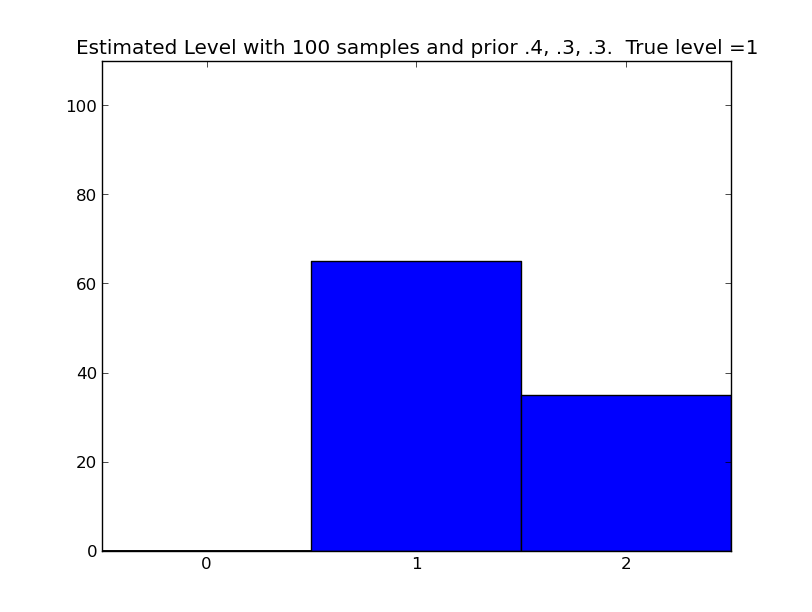

```python
from IPython.display import Image
Image('level_histogram.png')
```

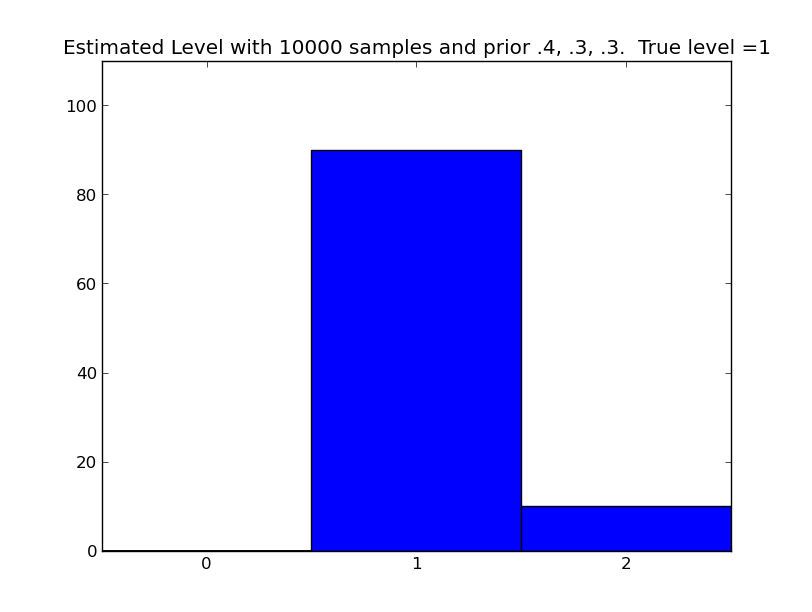

```python
Image('level_histogram2.png')
```

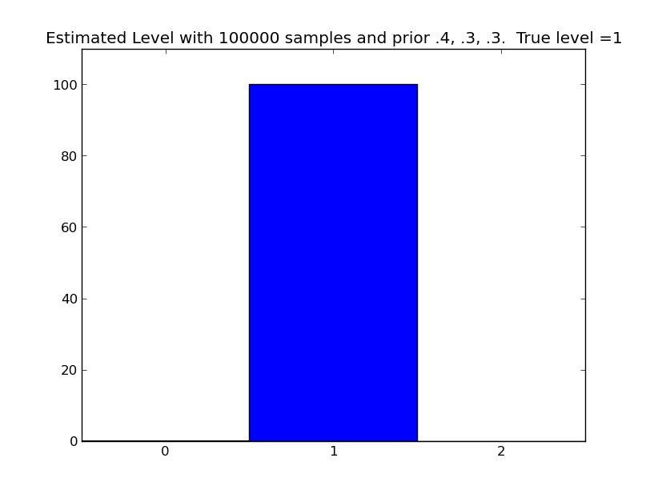

```python
Image('level_histogram3.png')
```

## Future

- Less Data